# Statsmodels_OLS_compared_to_Least_Squares_via_QR_Decomposition_updated

## Statsmodels Ordinary Least Squares compared to Linear Least Squares via QR Decomposition Southern Methodist University By Barry Daemi Updated: August 9, 2024 $$\newcommand{\C}{\mathbb{C}} \newcommand{\R}{\mathbb{R}} \newcommand{\Z}{\mathbb{Z}} \newcommand{\Q}{\mathbb{Q}} \newcommand{\P}{\mathbb{P}} \newcommand{\F}{\mathbb{F}} \newcommand{\N}{\mathbb{N}} \newcommand{\E}{\mathbb{E}}$$

### 1. Introduction

Unbeknownst to most, linear regression is the linear least squares problem from Linear algebra [[1](https://en.wikipedia.org/wiki/Least_squares)]; in fact many encounter the aforementioned linear least squares problem when taking a introductory course in Matrix algebra, though many times the purpose of said aforementioned mathematical algorithm is never genuinely explored in said classes, as time restrains don't allow for exploration or lack of interest on the part of the professor themself that lends to a lack of exploration on the topic. Regardless of the motative, the genuine exploration of the mathematical and theoretical origins of Oridinary Least Squares (e.g. linear regression) only really occures in advanced Economics (e.g., particularly Econometrics courses) and Statistics courses, which are in the tail-end of undergraduate progams, or most commonly found in Master's and PhD graduate programs.  
As a result, many do not know Ordinary Least Squares (e.g. linear regression) and linear Least squares are interchangeable terms for linear regression modeling, and fewer know how to derive and implement said algorithm from stratch. In this project, the objective is to derive and implement linear least squares via a QR decomposition algorithm in the Python object-oriented programming. The secondary objective is to demonstrate our implementation on a simple dataset, we borrowed a dataset `collegetown.xlsx` from Github *R Data Sets for Principles of Econometrics Fifth Edition* by Constantin Colonescu to create this demonstration. To validate our demonstration results we compared our results against the results that one could attaining through the use of Ordinary Least Squared algorithm from **Statsmodels**, which a widely utilized statistical and econometric Python package.

### 2. Linear Least Squares via QR Decomposition

The following code block contains imported Python packages that were utilized in this project, said packages included: `Numpy`, `Pandas`, `matplotlib.pyplot`, `Statsmodels`, `Scipy`, `copy` and `seaborn` and `IPython`. For the purpose of beautifying this Jupyter notebook custom CSS code was implemented through `IPython.core.display`'s HTML package, and for that reason the following code block contains CSS code.

```python
import numpy as np
import pandas as pd
import matplotlib.pyplot as plt
import statsmodels.api as sm
import scipy as sp
from scipy import stats
from scipy.stats import norm
import copy
import seaborn as sns
sns.set()
from IPython.core.display import HTML
HTML("""
<style>
ul.no-bullets {
  list-style-type: none;
  margin: 0;
  padding: 0;
}
table.GeneratedTable {
  width: 100%;
  background-color: #ffffff;
  border-collapse: collapse;
  border-width: 2px;
  border-color: #000000;
  border-style: solid;
  color: #000000;
}

table.GeneratedTable td, table.GeneratedTable th {
  border-width: 2px;
  border-color: #000000;
  border-style: solid;
  padding: 3px;
}

table.GeneratedTable thead {
  background-color: #3198ff;
}
</style>
""")
```

Suppose a dataset existed represented as $A \in \R^{m x n}$, its dimensions were $m$-by-$n$, in otherwords, m row dimensions and n column dimensions. Since $m \neq n$ are not equivalent the shape of the dataset matrix was rectangular, also where $m > n$ meant there were more equations then unknown variables in the linear system, which also meant it was a overdetermined system. From *Introduction to Linear Algebra, fifth edition* (Lin. Algebra) by Gilbert Strang [[2](https://math.mit.edu/~gs/linearalgebra/ila5/indexila5.html)], **rank** on pg. 139 is defined as,

**Definition of Rank.** *The rank of $A$ is the number of pivots. This number is $r$,*

where rank is determined by the number of pivots contained in matrix $A$. On pg. 47 from Lin. Algebra, pivots are defined as,

**Definition of Pivot.** *First nonzero, $a_{i,i}$ (diagonal elements), in the row that that does the (gaussian) elimination.*

**Definition of Rank - I.** *The rank of $A$ is the number of pivots. This number is $r=n$,*

1. All columns of $A$ are pivots columns.
2. There are no free variables or special solutions.
3. The nullspace $N(A)$ contains only zero vector $\overrightarrow{x}=0$.
4. If $Ax=b$ has a solution (it might not) then it has only *one solution*.

In turn since the column rank is $r=n$ that would mean that matrix $A$ is a full column ranked matrix; though in regards to its row rank, matrix $A$ is row rank-deficient matrix as this condition, $R \leq r$ will alway holds; as matrix $A$ will only possess a number of row pivots equal to or less than to the number column pivots it possesses, and therefore, matrix $A$ is considered a rank-deficient and overdetermined matrix.  
We have referred to pivots, but not the linearly independent vectors that contains these pivots; specifically a column pivot is contained inside a linearly independent column vector, likewise, a row pivot is self-contained inside a row vector. Think of linearly independence as a term regarding uniqueness, as each linearly independent vector points to a distinct (e.g. unique) direction, it adds an additional dimension to the subspace, or in other terms, the number of linearly independent vectors determines the geometric size of the space that said matrix $A$ occupies. To illustrate we have included an illustration from *Week 10: Supspaces, Linear Dependence* [[3](https://e.math.cornell.edu/people/belk/writing/LinearODEs10.pdf)] which corresponds from the *Linear Algebra and Ordinary Differential Equations Notes* series by Jim Belk of Cornell University [[4](https://e.math.cornell.edu/people/belk/)].

[figure not shown]

Figure 1 - Example of a linear subspace.

Suppose there existed an matrix $B \in \R^{3x3}$,

$$B=\begin{pmatrix} | & | & | \\ w & v & x \\ | & | & |\end{pmatrix} \tag{1}$$

where $w$ and $v$ are linearly independent column vectors, while $x$ was linearly dependent column vector that was a linear combination of $w$ and $v$; e.g., $x=a \cdot w + b \cdot v$ where $a,b \in R$ are constant scalars. The geometric space that is occupied by matrix $B$ is the area cover with all the linear combinations of $w$ and $v$, as these are column vectors the occupied area is called the **column space** of matrix $A$. A formal definition of **column space** can be borrowed from pg. 127 from Lin. Algebra,

**Definition 1.** *The **column space** consists of **all linear combinations of the columns** (e.g. column vectors). The combinations are all possible vectors from $Ax$. They fill the colume space $C(A)$.*

In essence these linearly independent vectors are the basis vectors of the linear subspace, and consequently form it. These basis vectors are the fundamental tools in solving $Ax=b$ for any given specified $b$. And thus, an additional note from pg. 127,

**Lemma 1.** *The system $Ax=b$ is solvable if and only if $b$ is in the column space of A (e.g. $C(A)$).*

The specified $b$ must be found within the column space of the respective matrix, as given the fact that the solution $x$ must result to the specified $b$ through a linear combination of the linearly independent and dependent vectors, the specified $b$ must be found within the column space, $b \in C(A)$.  
Referring back to the linear system represented by $B$,

$$Bx=\overrightarrow{b} \to \begin{pmatrix} | & | & | \\ w & v & x \\ | & | & |\end{pmatrix} \begin{pmatrix} x_{1} \\ x_{2} \\ x_{3} \end{pmatrix} = \begin{pmatrix} b_{1} \\ b_{2} \\ b_{3} \end{pmatrix} \tag{2}$$

so any specified $\overrightarrow{b}$ must be found inside the column space of matrix $B$, e.g. $ \overrightarrow{b} \in C(B)$, for there to be a solution $x$ to the linear system $Ax=\overrightarrow{b}$. This is due to the fact that the column space only occupies two dimensions of the three dimensional space, and can only attain solutions $x$ vectors with $b_{3}=0$, while the other elements can be formed with $b_{1},b_{2} \in \R$. For any given specified $\overrightarrow{b}$ not found within the column space of matrix $B$, $B \notin C(B)$, there does not exists a solution $x$ for $Ax=\overrightarrow{b}$, and so, $Ax\neq\overrightarrow{b}$.  
Applying these observations to matrix $A$, it can be inferred that that any given $b \notin C(A)$ will result with $Ax \neq b$. And due to the fact that matrix $A$ is a rectangular matrix it does not possess an inverse $A^{-1}$, but if $A^{T}$ was to be matrix-multiplied with $A$ itself, an invertible squared matrix could be formed, given if matrix $A$ possess a column rank equal to it column dimension, $r=n$, and thus possesses linearly independent columns. A formal definition from pg. 212 from Lin. Algebra,

**Lemma 2.** *$A^{T}A$ is invertible if and only if $A$ has linearly independent columns.*

Indeed the matrix $A$ must contain only linearly independent (e.g. unique) column vectors, for $A^{T}A$ to remain invertable, and so that the inverse conditions $(A^{T}A)^{-1}A^{T}A=I$ and $A^{T}A(A^{T}A)^{-1}=I$ are satisfied. Note the definition of an inverse matrix is as followed,

**Definition 2.** *The matrix $A$ is **invertable** if there exists a matrix $A^{-1}$ that "inverts" $A$*

$$\text{Two-sided inverse} \;\;\;\;\;\;\; A^{-1}A=I \;\; \text{and} \;\; AA^{-1}=I \;\;\;\;\;\;\;\;\;\;\;\;\;\;$$

this was borrowed from pg. 83 of Lin. Algebra. An inverse matrix (e.g. $A^{-1}$) is the matrix equivalent to the division operation (e.g. %) in scalar operations; as the traditional division operator, e.g. %, is not closed under vector space, the matrix inverse carries this function instead.  
When a given $b \notin C(A)$, and so, $Ax \neq b$, then matrix multiple $A^{T}$ on both side of the equation to attain $A^{T}A\hat{x}=A^{T}b$ formulation; this formula is called the normal equation, which unlike $Ax \neq b$ is a solvable linear system of equations. But instead of solving the normal equation for an exact solution, and an approximate solution named a least squares approximation $\hat{x}$ is attained through the following derivation,

$$A^{T}A\hat{x}=A^{T}b \to (A^{T}A)^{-1}A^{T}A\hat{x}=(A^{T}A)^{-1}A^{T}b \to \hat{x}=(A^{T}A)^{-1}A^{T}b,$$

$$\hat{x}=(A^{T}A)^{-1}A^{T}b \tag{3},$$

this least squares approximation minimizes the following lost function,

$$\text{Loss}=\Vert A \hat{x} - b \Vert. \tag{4}$$

Recollect that $Ax \neq b$ as $b \notin C(A)$, so $\text{Loss} = \Vert A \hat{x} - b \Vert \neq 0$, as no exact solution $x$ exists for this linear system, an approximate solution $\hat{x}$ must be attained by solving the normal equation, a solution of which minimizes the loss function, Eq 4.  
There is an issue with solving the normal equation $A^{T}A\hat{x}=A^{T}b$, it is a ill-conditioned approach to attaining the least square approximation $\hat{x}$; how is it ill-conditioned? Matrix $A$ is a function that maps between elements of $x=[x_{1},x_{2},\ldots,x_{m}]^{T}$ that are located in row space and to elements of $b=[b_{1},b_{2},\ldots,b_{n}]^{T}$ that are located in column space; specifically condition number is a ratio of the maximum to minimum stratching that is induced by matrix $A$. The Euclidean norm (e.g. 2-norm) is used to measure the stretch induced by mapping function $A$, specifically,

$$M=\Vert A \Vert = \max \frac{\Vert Ax \Vert}{\Vert x \Vert}, \tag{5}$$

is used to measure the maximum strecth by matrix $A$, while the following formulation,

$$m= \min \frac{\Vert Ax \vert}{\Vert x \Vert}, \tag{6}$$

is used to measure the minimum induced stretch. Eq 6 can be rewritten to the following form,

$$m= \min \frac{\Vert Ax \vert}{\Vert x \Vert}=\min \frac{\Vert Ax \Vert}{\Vert A^{-1}Ax \Vert} = \max \frac{1}{\frac{\Vert A^{-1}Ax \vert}{\Vert Ax \Vert}}=\max \frac{1}{\frac{\Vert A^{-1} \Vert \Vert Ax \vert}{\Vert Ax \Vert}} = \frac{1}{\vert A^{-1} \vert},$$

$$m=\frac{1}{\Vert A^{-1} \Vert}. \tag{7}$$

Consequently the condition number of a matrix is represented by,

$$\kappa(A)=\frac{M}{m}, \tag{8}$$

where $\kappa(A)$ is condition number for matrix $A$. Substituting into Eq 5 and Eq 6 into Eq 8,

$$\kappa(A)=\frac{M}{m}=\frac{\max \frac{\Vert Ax \Vert}{\Vert x \Vert}}{\min \frac{\Vert Ax \vert}{\Vert x \Vert}} = \frac{\frac{\Vert Ax \Vert}{\Vert x \Vert}}{\frac{1}{\Vert A^{-1} \Vert}}=\frac{\Vert Ax \Vert \Vert A^{-1} \Vert}{\Vert x \Vert} = \frac{\Vert A \Vert \Vert x \Vert \Vert A^{-1} \Vert}{\Vert x \Vert} = \Vert A \Vert \Vert A^{-1} \Vert$$

$$\kappa(A)=\Vert A \Vert \Vert A^{-1} \Vert. \tag{9}$$

With Eq 9, we are able computate the matrix condition number for $A^{T}A$, which attributes to the computational complexity of the normal form $A^{T}A\hat{x}=A^{T}b$.  
Instead of solving the normal equation $A^{T}A\hat{x}=A^{T}b$ directly, we can modify it through applying QR decomposition to it,

$$A^{T}A\hat{x}=A^{T}b \to (QR)^{T}QR\hat{x}=(QR)^{T}b \to R^{T}Q^{T}QR\hat{x}=R^{T}Q^{T}b \to R^{T}R\hat{x}=R^{T}Q^{T}b$$

$$\to R^{-T}R^{T}R\hat{x}=R^{-T}R^{T}Q^{T}b \to R\hat{x}=Q^{T}b,$$

$$R\hat{x}=Q^{T}b, \tag{10}$$

given $A=QR$ through QR decomposition, and as $Q$ in an unitary matrix, then $Q^{T}Q=I$ and $QQ^{T}=I$, where $I$ is the identity matrix. With Eq 10, to attain the least squares approximation $\hat{x}$, only the inverse of $R$ needs to be calculated and matrix multiplied with $Q^{T}b$,

$$R\hat{x}=Q^{T}b \to R^{-1}R\hat{x}=R^{-1}Q^{T}b \to \hat{x}=R^{-1}Q^{T}b,$$

$$\hat{x}=R^{-1}Q^{T}b, \tag{11}$$

the computational complexity of Eq 11 is $O(mn^{2})$, which is much better than the Normal equations computational complexity of $O(n^{3})$.  
Let's computate the matrix condition number for $\kappa(A^{T}A)$ and $\kappa((QR)^{T}QR)$: first let's do $\kappa(A^{T}A)$,

$$\kappa(A) = \Vert A \Vert \Vert A^{-1} \Vert \to \kappa(A^{T}A)=\Vert A^{T}A \Vert \Vert (A^{T}A)^{-1} \Vert = \Vert A^{T}A \Vert \Vert A^{-1}A^{-T} \Vert$$

$$= \Vert A^{T} \Vert \Vert A\Vert \Vert A^{-1} \Vert A^{-T} \Vert = \Vert A \Vert^{2} \Vert A^{-1} \Vert^{2} = \big( \Vert A \Vert \Vert A^{-1} \Vert \big)^{2} =\kappa(A)^{2}$$

$$\kappa(A^{T}A)=\kappa(A)^{2}, \tag{12}$$

subsequently let's do $\kappa((QR)^{T}QR)$,

$$\kappa((QR)^{T}QR)=\Vert (QR)^{T}QR \Vert \big\Vert \big((QR)^{T}QR\big)^{-1} \big\Vert \to \kappa(R^{T}Q^{T}QR)=\Vert R^{T}Q^{T}QR \Vert \big\Vert \big((R^{T}Q^{T}QR\big)^{-1} \big\Vert$$

$$\kappa(R^{T}R)=\Vert R^{T}R \Vert \Vert \big((R^{T}R\big)^{-1} \Vert = \Vert R^{T}R \Vert \Vert R^{-1} R^{-T} \Vert = \Vert R^{T} \Vert \Vert R \Vert \Vert R^{-1} \Vert R^{-T} \Vert$$

$$=\Vert R \Vert^{2} \Vert R^{-1} \Vert^{2} = \big( \Vert R \Vert \vert R^{-1} \Vert \big) = \kappa(R)^{2},$$

$$\kappa(R^{T}R)=\kappa(R)^{2}, \tag{13}$$

since $\kappa((QR)^{T}QR)=\kappa(R^{T}R)$. Finally let computate $\kappa(A)$ with QR decomposition applied to the right side of the equation:

$$\kappa(A)=\Vert A \Vert \Vert A^{-1} \Vert = \Vert QR \Vert \Vert (QR)^{-1} \Vert = \Vert QR \Vert \Vert R^{-1}Q^{-1} \Vert = \Vert Q \Vert \Vert R \Vert \Vert R^{-1} \Vert \Vert Q^{-1} \Vert$$

$$=\Vert R \Vert \Vert R^{-1} \Vert,$$

$$\kappa(A)=\Vert R \Vert \Vert R^{-1} \Vert, \tag{14}$$

we attained that reducing matrix $A$ to an upper triangular matrix $R$ does not improve the condition number of a linear system, and so, if a linear system is highly ill-conditioned - it will remain highly ill-condition despite this partial row reduced echelon form transformation. Instead the benefit of this alternative approach is that reducing matrix $A$ to upper triangular form $R$ reduces the computational complexity of backward substitution from $O(n^{3})$ to $O(n^{2})$, and the condition number of the transform system is $\kappa(R)$ instead of $\kappa(A)^{2}$ which is a sqaure root reduction in condition.

### 3. Implementation of Linear Least Squares via QR Decomposition

In the last section we developed the mathematical framework for the linear least squares problem and the approaches to solve said linear least squares problem. This section will be focused on the implementation of linear least squares via QR decomposition; to begin, we need to import `collegetown.xlsx` from *R Data Sets for Principles of Econometrics Fifth Edition* by Constantin Colonescu; the imported data was named `df`.

```python
df=pd.read_excel("collegetown.xlsx");
df
```

|  | price | sqft | age | pool | fireplace | close | twostory | occupied |
| --- | --- | --- | --- | --- | --- | --- | --- | --- |
| 0 | 96.5 | 16.77 | 10 | 0 | 0 | 0 | 0 | 0 |
| 1 | 106.0 | 17.51 | 10 | 0 | 0 | 0 | 0 | 0 |
| 2 | 114.0 | 18.37 | 9 | 0 | 0 | 0 | 0 | 1 |
| 3 | 119.9 | 29.10 | 9 | 0 | 0 | 0 | 0 | 0 |
| 4 | 122.7 | 14.68 | 9 | 0 | 0 | 0 | 0 | 1 |
| ... | ... | ... | ... | ... | ... | ... | ... | ... |
| 495 | 350.0 | 25.21 | 11 | 0 | 1 | 1 | 1 | 1 |
| 496 | 207.0 | 19.17 | 10 | 0 | 0 | 1 | 0 | 1 |
| 497 | 270.0 | 21.04 | 10 | 0 | 1 | 1 | 0 | 1 |
| 498 | 296.0 | 32.55 | 10 | 0 | 1 | 1 | 0 | 1 |
| 499 | 470.0 | 29.49 | 8 | 0 | 1 | 1 | 1 | 1 |

500 rows × 8 columns

The dataset `collegetown.xlsx` is housing data from a real college town, though the textbook does not specify which. Anyhow, the data columns were seperated into dataframe $A$, and the target variable into a dataframe $b$; to illustrate matrix $A$, it was printed to console.

```python
list_Label=list(df.columns);
A=df[list_Label[1:len(list_Label)]];
b=df['price'];

# prints dataframes A and b to console
print("A = ");
print(A);
```

```
A =
      sqft  age  pool  fireplace  close  twostory  occupied
0    16.77   10     0          0      0         0         0
1    17.51   10     0          0      0         0         0
2    18.37    9     0          0      0         0         1
3    29.10    9     0          0      0         0         0
4    14.68    9     0          0      0         0         1
..     ...  ...   ...        ...    ...       ...       ...
495  25.21   11     0          1      1         1         1
496  19.17   10     0          0      1         0         1
497  21.04   10     0          1      1         0         1
498  32.55   10     0          1      1         0         1
499  29.49    8     0          1      1         1         1

[500 rows x 7 columns]
```

Hence matrix $A \in \R^{500x7}$ and $b \in R^{500x1}$, given $m > n$ matrix $A$ is a rectangular matrix, with a given column rank (e.g. $r$) of $r \leq n$ and a given row rank (e.g. $R$) of $R \leq r$. To attain the column and row ranks of matrix $A$, `np.linalg.matrix_rank()` was executed with $A$ and $A^{T}$.

```python
print("Column Rank of A: "+ str(np.linalg.matrix_rank(np.array(A))))
print("Row Rank of A: " + str(np.linalg.matrix_rank(np.array(A).T)))
```

```
Column Rank of A: 7
Row Rank of A: 7
```

As expected matrix $A$ possesses a column rank $r=n=7$ and a row rank $R=7 < m=500$, and so, matrix $A$ possesses linearly independent columns as required with **Lemma 2**. As matrix $A$ has linearly independent columns, $A^{T}A$ is an invertable matrix.  
To demonstrate the importance of **Lemma 2**, we created the following numerical experiment: matrix $A^{T}A$ alongside it inverse $(A^{T}A)^{-1}$ were generated, from **Definition 2** we know that $A^{-1}A=I$ and $AA^{-1}=I$, let's verify this theorem with this experiment.

```python
ATA=A.T@A
ATA
```

|  | sqft | age | pool | fireplace | close | twostory | occupied |
| --- | --- | --- | --- | --- | --- | --- | --- |
| sqft | 424539.054 | 110102.4 | 1097.54 | 8399.75 | 5025.53 | 2621.08 | 7958.59 |
| age | 110102.400 | 35217.0 | 247.00 | 2083.00 | 1624.00 | 555.00 | 2251.00 |
| pool | 1097.540 | 247.0 | 32.00 | 24.00 | 7.00 | 4.00 | 19.00 |
| fireplace | 8399.750 | 2083.0 | 24.00 | 273.00 | 114.00 | 52.00 | 169.00 |
| close | 5025.530 | 1624.0 | 7.00 | 114.00 | 189.00 | 35.00 | 110.00 |
| twostory | 2621.080 | 555.0 | 4.00 | 52.00 | 35.00 | 69.00 | 41.00 |
| occupied | 7958.590 | 2251.0 | 19.00 | 169.00 | 110.00 | 41.00 | 280.00 |

```python
X=np.random.randn(7);
print("Determinant of ATA: " + "\n" + "Det(ATA) = " + str(np.linalg.det(ATA)));
print(" ");
print("Eigenvalues of ATA: " + "\n" + "\u03BB = " + str(np.linalg.eig(ATA)[0]));
print(" ");
print("Symmetric condition: " + " \n " + "X^{T}@ATA@X = " + str(X.T@ATA@X) + " > 0")
```

```
Determinant of ATA:
Det(ATA) = 5.733199746879585e+18

Eigenvalues of ATA:
λ = [4.53915283e+05 6.25972838e+03 2.82383288e+01 4.85701244e+01
 1.41984130e+02 8.95682276e+01 1.15681733e+02]

Symmetric condition:
 X^{T}@ATA@X = 798811.8641721151 > 0
```

```python
np.linalg.inv(ATA)@ATA
```

|  | sqft | age | pool | fireplace | close | twostory | occupied |
| --- | --- | --- | --- | --- | --- | --- | --- |
| 0 | 1.000000e+00 | -7.467442e-17 | 3.523657e-19 | -1.086913e-17 | -9.486769e-18 | -2.195509e-18 | -2.081668e-17 |
| 1 | 1.838400e-15 | 1.000000e+00 | 1.038124e-17 | 3.071003e-17 | 3.745919e-17 | 2.377113e-17 | 0.000000e+00 |
| 2 | 1.561742e-14 | 5.978616e-15 | 1.000000e+00 | 4.333556e-16 | 2.053479e-16 | 1.245748e-16 | 4.163336e-16 |
| 3 | -3.001899e-14 | -4.033449e-15 | -2.797242e-17 | 1.000000e+00 | -7.502679e-17 | -4.575333e-17 | 0.000000e+00 |
| 4 | 1.162670e-14 | 4.974265e-15 | 2.986977e-17 | 2.630817e-16 | 1.000000e+00 | 3.409816e-17 | 3.191891e-16 |
| 5 | 1.759587e-15 | 4.688090e-16 | 7.372575e-18 | -1.374768e-16 | 2.194425e-16 | 1.000000e+00 | 0.000000e+00 |
| 6 | -2.574132e-15 | -3.131176e-15 | -8.673617e-18 | -5.377643e-17 | 1.075529e-16 | 1.734723e-18 | 1.000000e+00 |

Consequentially $A^{T} \cdot A = A^{T}A$, where $A^{T}A \in \R^{7x7}$ is a symmetric-positive-definite (SPD) matrix; the symmetric condition is as followed,

**Definition 3.** *A **symmetric matrix** has $S^{T}=S$. This means that $s_{ji}=s_{ij}$.*

pg. 111 from Lin. Algebra. In essence the tranposed matrix $A^{T}$ should equal the original matrix $A$, in terms of elements, it means non-diagonal elements should have pairs within the matrix in both cases. In terms of $A^{T}A$,

```python
ATA
```

|  | sqft | age | pool | fireplace | close | twostory | occupied |
| --- | --- | --- | --- | --- | --- | --- | --- |
| sqft | 424539.054 | 110102.4 | 1097.54 | 8399.75 | 5025.53 | 2621.08 | 7958.59 |
| age | 110102.400 | 35217.0 | 247.00 | 2083.00 | 1624.00 | 555.00 | 2251.00 |
| pool | 1097.540 | 247.0 | 32.00 | 24.00 | 7.00 | 4.00 | 19.00 |
| fireplace | 8399.750 | 2083.0 | 24.00 | 273.00 | 114.00 | 52.00 | 169.00 |
| close | 5025.530 | 1624.0 | 7.00 | 114.00 | 189.00 | 35.00 | 110.00 |
| twostory | 2621.080 | 555.0 | 4.00 | 52.00 | 35.00 | 69.00 | 41.00 |
| occupied | 7958.590 | 2251.0 | 19.00 | 169.00 | 110.00 | 41.00 | 280.00 |

```python
ATA.T
```

|  | sqft | age | pool | fireplace | close | twostory | occupied |
| --- | --- | --- | --- | --- | --- | --- | --- |
| sqft | 424539.054 | 110102.4 | 1097.54 | 8399.75 | 5025.53 | 2621.08 | 7958.59 |
| age | 110102.400 | 35217.0 | 247.00 | 2083.00 | 1624.00 | 555.00 | 2251.00 |
| pool | 1097.540 | 247.0 | 32.00 | 24.00 | 7.00 | 4.00 | 19.00 |
| fireplace | 8399.750 | 2083.0 | 24.00 | 273.00 | 114.00 | 52.00 | 169.00 |
| close | 5025.530 | 1624.0 | 7.00 | 114.00 | 189.00 | 35.00 | 110.00 |
| twostory | 2621.080 | 555.0 | 4.00 | 52.00 | 35.00 | 69.00 | 41.00 |
| occupied | 7958.590 | 2251.0 | 19.00 | 169.00 | 110.00 | 41.00 | 280.00 |

$(A^{T}A)^{T}=A^{T}A$, as $A^{T}A$ is a symmetric matrix. Borrowing from [[5](https://math.emory.edu/~lchen41/teaching/2020_Fall/Section_8-3.pdf)], which also is borrowed from *Linear Algebra with Applications, Open Edition* by W. Keith Nicholson,

**Definition 4. (Positive Definite Matrices)** *A square matrix is called **positive definite** if it is a symmetric and all its eigenvalues $\lambda$ are positive, that is $\lambda > 0$.*

as matrix is symmetric and all its eigenvalues $\lambda$ are positive, $\lambda > 0$, matrix $A^{T}A$ is thus also considered a positive definite matrix. And therefore matrix $A^{T}A$ is a symmetric positive definite matrix, which make linear least squares a strictly convex problem; a further read resource on convex optimization can be found here [[6](https://cs229.stanford.edu/section/cs229-cvxopt.pdf)]. Additional conditions to prove positive-definite-ness from [[5](https://math.emory.edu/~lchen41/teaching/2020_Fall/Section_8-3.pdf)] can be found below:

**Theorem 1.** *If $A$ is positive definite, then it is invertible and det(A) >0.*

**Theorem 2.** *A symmetric matrix $A$ is positive definite if and only if $x^{T}Ax>0$ for every column $x \neq 0$ in $\R^{n}$.*

Regardless we also proved that matrix $A^{T}A$ also met these conditions in the numerical experiment above.  
Suppose a matrix $B \in \R^{500x9}$, it possesses a column rank of $r=7$, and therefore possesses two linearly dependent columns: "AdjSqft" and "AdjPrice". Matrix $B$ does not have linearly independent column, in fact it is rank-deficient in both column and row spaces.

```python
df['AdjSqft']=2*df['sqft']+2*df['age'];
df['AdjPrice']=2*df['age']+3*df['sqft'];
list_Label=list(df.columns);
B=df[list_Label[1:len(list_Label)]];
print("B = ");
print(B);
print(" ");
print("Column Rank of B: "+ str(np.linalg.matrix_rank(np.array(B))));
print("Row Rank of B: " + str(np.linalg.matrix_rank(np.array(B).T)));
```

```
B =
      sqft  age  pool  fireplace  close  twostory  occupied  AdjSqft  AdjPrice
0    16.77   10     0          0      0         0         0    53.54     70.31
1    17.51   10     0          0      0         0         0    55.02     72.53
2    18.37    9     0          0      0         0         1    54.74     73.11
3    29.10    9     0          0      0         0         0    76.20    105.30
4    14.68    9     0          0      0         0         1    47.36     62.04
..     ...  ...   ...        ...    ...       ...       ...      ...       ...
495  25.21   11     0          1      1         1         1    72.42     97.63
496  19.17   10     0          0      1         0         1    58.34     77.51
497  21.04   10     0          1      1         0         1    62.08     83.12
498  32.55   10     0          1      1         0         1    85.10    117.65
499  29.49    8     0          1      1         1         1    74.98    104.47

[500 rows x 9 columns]

Column Rank of B: 7
Row Rank of B: 7
```

When `np.linalg.matrix_rank()` was applied to $B$, it resulted that matrix $B$ had column rank of $r=7 < n=9$ and row rank of $R=7 < m = 500$; this was an expected result, as there are only seven linearly independent columns in matrix $B$, which is enough to span $\R^{7}$ not $\R^{9}$. What about $B^{T}B$ denoted `BTB` in the script:

```python
BTB=B.T@B
BTB
```

|  | sqft | age | pool | fireplace | close | twostory | occupied | AdjSqft | AdjPrice |
| --- | --- | --- | --- | --- | --- | --- | --- | --- | --- |
| sqft | 424539.054 | 110102.4 | 1097.54 | 8399.75 | 5025.53 | 2621.08 | 7958.59 | 1069282.908 | 1493821.962 |
| age | 110102.400 | 35217.0 | 247.00 | 2083.00 | 1624.00 | 555.00 | 2251.00 | 290638.800 | 400741.200 |
| pool | 1097.540 | 247.0 | 32.00 | 24.00 | 7.00 | 4.00 | 19.00 | 2689.080 | 3786.620 |
| fireplace | 8399.750 | 2083.0 | 24.00 | 273.00 | 114.00 | 52.00 | 169.00 | 20965.500 | 29365.250 |
| close | 5025.530 | 1624.0 | 7.00 | 114.00 | 189.00 | 35.00 | 110.00 | 13299.060 | 18324.590 |
| twostory | 2621.080 | 555.0 | 4.00 | 52.00 | 35.00 | 69.00 | 41.00 | 6352.160 | 8973.240 |
| occupied | 7958.590 | 2251.0 | 19.00 | 169.00 | 110.00 | 41.00 | 280.00 | 20419.180 | 28377.770 |
| AdjSqft | 1069282.908 | 290638.8 | 2689.08 | 20965.50 | 13299.06 | 6352.16 | 20419.18 | 2719843.416 | 3789126.324 |
| AdjPrice | 1493821.962 | 400741.2 | 3786.62 | 29365.25 | 18324.59 | 8973.24 | 28377.77 | 3789126.324 | 5282948.286 |

```python
print("Dimensions of matrix B^{T}B: " + str(np.array(BTB).shape));
print("Column Rank of B^{T}B: "+ str(np.linalg.matrix_rank(np.array(B.T@B))));
print("Row Rank of B^{T}B: " + str(np.linalg.matrix_rank((np.array(B).T@B).T)));
```

```
Dimensions of matrix B^{T}B: (9, 9)
Column Rank of B^{T}B: 7
Row Rank of B^{T}B: 7
```

Since matrix $B$ is a rank-deficient matrix both in column and row spaces, the matrix multiplication trick $B^[T] \cdot B = B^{T}B$ did not form a symmetric positive definite matrix, instead it form a rank-deficient symmetric matrix. As we know $B^{T}B$ is symmetric by **Definition 3**, the following test were to verify the positive definite claim.

```python
X=np.random.randn(9);
print("Determinant of BTB: " + "\n" + "Det(BTB) = " + str(np.linalg.det(BTB)));
print(" ");
print("Singular Values of BTB: " + "\n" + "\u03BB = " + str(np.linalg.svd(BTB)[1]**2));
print(" ");
print("Symmetric condition: " + " \n " + "X^{T}@BTB@X = " + str(X.T@BTB@X) + " > 0")
```

```
Determinant of BTB:
Det(BTB) = 0.4723131223293807

Singular Values of BTB:
λ = [7.14742769e+13 7.60449685e+07 2.02171514e+04 1.33825601e+04
 8.02961579e+03 2.35983036e+03 7.97417706e+02 3.75812148e-19
 5.05094491e-21]

Symmetric condition:
 X^{T}@BTB@X = 49614443.0834224 > 0
```

Since $B$ and $B^{T}B$ are both rank-deficient matrices, to attain the eigenvalues of $B^{T}B$, a Singular value decomposition must be executed with $B^{T}B$, and the resulting singular values must be squared. By **Definition 4** matrix $B^{T}B$ is not a positive definite matrix, due to the fact that not all of its eiginvalues $\lambda$ are positive, $\lambda > 0$, and two of them are equal to zeros, e.g., $\lambda_{8}=$ and $\lambda_{9}=0$. To test **Lemma 2** and **Definition 2**, the inverse of $B^{T}B$ was computate $(B^{T}B)^{-1}$, and matrix multipled $B^{T}B$, e.g. $(B^{T}B)^{-1}B^{T}B$.

```python
np.linalg.inv(BTB)@BTB
```

|  | sqft | age | pool | fireplace | close | twostory | occupied | AdjSqft | AdjPrice |
| --- | --- | --- | --- | --- | --- | --- | --- | --- | --- |
| 0 | -1.128525e+00 | 2.966364e-01 | 7.127069e-03 | 1.055504e-01 | 5.933572e-02 | 2.971326e-02 | 7.122424e-02 | 8.057400e+00 | 1.165005e+01 |
| 1 | -7.340658e+00 | 1.523431e-01 | -8.236742e-03 | -8.772254e-02 | -4.550850e-02 | -3.552710e-02 | -7.239661e-02 | -7.649294e+00 | -1.826262e+01 |
| 2 | 2.042411e-13 | 1.142302e-14 | 1.000000e+00 | 1.987729e-15 | 6.803002e-16 | 7.907748e-16 | 2.726442e-15 | 4.419046e-13 | 3.156615e-13 |
| 3 | -1.714545e-14 | 1.424605e-14 | 9.861871e-17 | 1.000000e+00 | 9.454340e-16 | 2.127055e-17 | -5.644608e-16 | -3.372068e-14 | 7.753139e-14 |
| 4 | 1.197144e-14 | 3.810426e-15 | 8.549263e-19 | 3.019808e-16 | 1.000000e+00 | 1.341050e-16 | -1.180533e-17 | -1.357044e-14 | 5.984824e-14 |
| 5 | 2.338688e-13 | 2.681937e-14 | 3.294748e-16 | 3.712207e-15 | -1.062759e-15 | 1.000000e+00 | 3.493336e-15 | -1.073214e-13 | 1.515489e-13 |
| 6 | 7.309145e-15 | -6.100164e-15 | -4.581709e-17 | -7.054090e-18 | -1.089278e-15 | 3.909224e-19 | 1.000000e+00 | -6.571592e-14 | -1.995925e-14 |
| 7 | -2.510096e-01 | -1.287570e-01 | -1.003701e-03 | -9.438396e-04 | -4.990613e-03 | -1.724340e-03 | -2.163040e-03 | 3.706398e-01 | -2.250197e+00 |
| 8 | 1.970855e+00 | 1.765695e-01 | 4.418338e-03 | 1.400558e-02 | 1.697894e-02 | 2.903189e-03 | 1.504058e-02 | 2.801009e+00 | 5.778024e+00 |

Since matrix $B$ did not possess linearly independent columns, by **Lemma 2** $B^{T}B$ is not an invertable matrix; though despite this fact, Numpy's `linalg.inv()` can still implement Gaussian Elimination to attain a pseudo-inverse matrix $(B^{T}B)^{+}$, which cannot satisfy **Definition 2.**, as it is not a genuine inverse matrix, and so, $(B^{T}B)^{+}B^{T}B \neq I$. This is an critical issue, as the normal equation become intractable $B^{T}B\hat{x}=B^{T}b$, and so, $(B^{T}B)^{+}B^{T}B\hat{x} \neq (B^{T}B)^{+}B^{T}b$ given to the fact $(B^{T}B)^{+}B^{T}B \neq I$. The issue of rank-deficiency occurs when two or more statistically independent variables possess exact linear relationships amongst themselves, this is called perfect multicollinearity pg. 1 [[7](https://www.sfu.ca/~dsignori/buec333/lecture%2016.pdf)], it means that statistically independent but linearly dependent variables are linear combinations of the linearly independent variables, in our case,

$$\text{'AjdSqft'}=2 \cdot \text{'sqft'} + 2 \cdot \text{'age'}, \tag{15}$$

$$\text{'AjdPrice'}=2 \cdot \text{'age'} + 3 \cdot \text{'sqft'}. \tag{16}$$

As $B^{T}B$ needs to become invertable for the normal equations $B^{T}B\hat{x}=B^{T}b$ to become tractable, the linearly dependent variables must be dropped from $B^{T}B$.  
Instead when a matrix $B^{T}B$ is full-rank but near or close to rank-deficient, then there exists imperfect multicollinearity amongst two or more of the statistically independent variables; imperfect multicollinearity can be detected when two or more statistically independent variables share a correlation coefficient $\rho$ in the following interval, $ 0.80 < \rho > 1.00$. Why so? Recall that linear independence of a vector is uniqueness in the pointing direction of that vector, so suppose there existed two linearly independent vectors $\overrightarrow{u} \in \R^{n}$ and $\overrightarrow{w} \in R^{n}$, the angle between these two linearly independent vectors is $\theta$. The angle between these $\overrightarrow{u}$ and $\overrightarrow{w}$ can be found within the interval, $[0,\pi]$: $\theta=0$ and $\theta=\pi$ means that $u=c \cdot w$ or $w=c \cdot u$ where $c \in \R$ and so $\overrightarrow{u}$ or $\overrightarrow{w}$ is a linear scaling of the other (e.g. one is linearly independent and the other is linearly dependent); when $\theta=\frac{\pi}{2}$, then $\overrightarrow{u}$ and $\overrightarrow{w}$ are orthogonal vectors, where $\overrightarrow{u}^{T}\overrightarrow{w}=0$ and thus both vectors are linearly independent. The angle $\theta$ between the vectors corresponds to the correlation coefficient, or the degree of correlation between $\overrightarrow{u}$ and $\overrightarrow{w}$; an approximate relation would be $0.01111\ldots$ correlation for every 1 degree (or 0.0174533 radian), and so, imperfect multicollinearity occurs when $\rho \in (0.80,1.00)$, or in terms of an angle, multicollinearity occurs when $\theta$ fall within the interval $ 0^{\circ} < \theta < 37^{\circ}$ (or $0 < \theta < \frac{41\pi}{200}$).  
Other methods to detect multicollinearity are outline on pg. 5 from [[7](https://www.sfu.ca/~dsignori/buec333/lecture%2016.pdf)]:

**The Detection of Multicollinearity.**

1. **High Correlation Coefficents**: Pairwise correlation among (statistically) independent variables might be high (in absolute value). Rule of thumb: If the correlation $>0.8$ then severe multicollinearity may be present.
2. **High $R^{2}$ with low t-Statistic Values**: Possible for individual regression coefficients to be insignificant but for the overall fit of the equation to be high.
3. **High Variance Inflation Factors (VIFs)**: A VIF measures the extent to which multicollinearity has increased the variance of an estimated coefficient. It looks at the extent to which an explanatory variable can be explained by all the other explanatory variables in the equation.

On pg. 4 of [[7](https://www.sfu.ca/~dsignori/buec333/lecture%2016.pdf)], the author outlines the effects of multicollinearity on linear regression:

**The Consequences of Multicollinearity.**

1. Imperfect multicollinearity does not violate Assumption 5 (Gauss-Markov Theorem). Therefore the Gauss-Markov Theorem tells us that OLS estimators are BLUE (e.g. Best Linear Unbiased Estimators).
2. The variances and the standard erros of the regression coefficient estimates will increase. This means lower t-statistics.
3. The overall fit of the regression equation will be largely unaffected by multicollinearity. This also means that forecasting and prediction will be largely unaffected.
4. Regression coefficients will be sensitive to specifications. Regression coefficients can change substantially when variables are added or dropped.

If imperfect multicollinearity is present in a linear regression model, and one desires to eliminate it from the model, one could drop redundant variables from the model, and or, add non-redundant variable to replace redundant variables.  
An additional note, if matrix $B$ is close or near rank-deficient, then least squares via Singular value decomposition (SVD) would be the preferred method to attain the least squares approximation, $\hat{x}$. The following is the derivation for attaining least squares via SVD:

$$B\hat{x}=b \to U \Sigma V^{T} \hat{x}=b \to U^{T}U \Sigma V^{T} \hat{x} = U^{T}b \to \Sigma V^{T} \hat{x} = U^{T}b \to \Sigma^{-1} \Sigma V^{T} \hat{x} = \Sigma^{-1} U^{T}b$$

$$V^{T} \hat{x} = \Sigma^{-1} U^{T}b, \tag{17}$$

this modified linear system, Eq 17, possessess a condition number of $\kappa(V^{T})$ and a computational complexity of $O(2mn^{2}+11n^{3})$; least squares via SVD is a computationally expensive algorithm with exceeding robustness and stability; e.g. note condition number, it is quite small - $V^{T}$ is an unitary matrix. Though we will not implement least squares via SVD in this project; it was important to address the question on how to handle close to rank-deficient matrices.  
Now onto the QR algorithm itself: we chose to implement QR decomposition by givens rotation transformation, though it is the most expensive implementation of the QR algorithm, it also is the most computationally stable between (non-modified and modified) Gram-Schmidt orthonormalization process and Household reflection transformation approachs. QR by givens rotation is an algorithmic approach where a sequence of given rotation matrices slowly transform matrix $A$ into a upper triangular matrix $R$; the following is the general Givens rotation matrix,

$$G=\begin{pmatrix} c & -s & 0 & 0 & \cdots & 0 \\ s & c & 0 & 0 & \ldots & 0 \\ 0 & 0 & 1 & 0 & \ldots & 0 \\ \vdots & \vdots & \vdots & \ddots & \vdots & \vdots \\ 0 & 0 & 0 & 0 & \cdots & 1\end{pmatrix} \tag{18}$$

where $c$ represents $\cos(\theta)$ and $s$ represents $\sin(\theta)$, though $\cos(\theta)$ and $\sin(\theta)$ are not explicitly computate but instead computate through normalized unit circle coordinates through the following formulation:

$$c_{i,j}=\cos(\theta)=\frac{x_{i,j}}{\sqrt{x_{i,j}^{2}+x_{i+1,j}^{2}}} \tag{19}$$

and,

$$s_{i,j}=\sin(\theta)=\frac{-x_{i+1,j}}{\sqrt{x_{i+1,j}^{2}+x_{i,j}^{2}}}. \tag{20}$$

Without delving into too many details, the following Python function, `givensrotation(a,b)` is the Python implementation of given rotation matrices, and furthermore a efficient implementation of the schema.

```python
def givensrotation(a,b):
    if b==0:
        c=1;
        s=0;
    else:
        if np.abs(b) > abs(a):
            r=a/b;
            s=1/np.sqrt(1+r**2);
            c=s*r;
        else:
            r=b/a;
            c=1/np.sqrt(1+r**2);
            s=c*r;

    return c,s;
```

Suppose a matrix $A \in \R^{3x3}$ existed, which was a full-rank square matrix.

$$A=\begin{pmatrix} a_{1,1} & a_{1,2} & a_{1,3} \\ a_{2,1} & a_{2,2} & a_{2,3} \\ a_{3,1} & a_{3,2} & a_{3,3} \end{pmatrix} \tag{21}$$

Further that QR decomposition was applied to said matrix $A$:

$$G_{1,1} \cdot A = \begin{pmatrix} 1 & 0 & 0 \\ 0 & c_{1,1} & -s_{1,1} \\ 0 & s_{1,1} & c_{1,1} \end{pmatrix} \begin{pmatrix} a_{1,1} & a_{1,2} & a_{1,3} \\ a_{2,1} & a_{2,2} & a_{2,3} \\ a_{3,1} & a_{3,2} & a_{3,3} \end{pmatrix} = \begin{pmatrix} a_{1,1} & a_{1,2} & a_{1,3} \\ \tilde{a}_{2,1} & \tilde{a}_{2,2} & \tilde{a}_{2,3} \\ 0 & \tilde{a}_{3,2} & \tilde{a}_{3,3} \end{pmatrix}$$

$$G_{2,1} \cdot G_{1,1} \cdot A = \begin{pmatrix} c_{2,1} & -s_{2,1} & 0 \\ s_{2,1} & c_{2,1} & 0 \\ 0 & 0 & 1 \end{pmatrix} \begin{pmatrix} a_{1,1} & a_{1,2} & a_{1,3} \\ \tilde{a}_{2,1} & \tilde{a}_{2,2} & \tilde{a}_{2,3} \\ 0 & \tilde{a}_{3,2} & \tilde{a}_{3,3} \end{pmatrix} = \begin{pmatrix} \hat{a}_{1,1} & \hat{a}_{1,2} & \hat{a}_{1,3} \\ 0 & \hat{a}_{2,2} & \hat{a}_{2,3} \\ 0 & \tilde{a}_{3,2} & \tilde{a}_{3,3} \end{pmatrix}$$

$$G_{1,2} \cdot G_{2,1} \cdot G_{1,1} \cdot A = \begin{pmatrix} 1 & 0 & 0 \\ 0 & c_{1,2} & -s_{1,2} \\ 0 & s_{1,2} & c_{1,2} \end{pmatrix} \begin{pmatrix} \hat{a}_{1,1} & \hat{a}_{1,2} & \hat{a}_{1,3} \\ 0 & \hat{a}_{2,2} & \hat{a}_{2,3} \\ 0 & \tilde{a}_{3,2} & \tilde{a}_{3,3} \end{pmatrix} = \begin{pmatrix} \hat{a}_{1,1} & \hat{a}_{1,2} & \hat{a}_{1,3} \\ 0 & \ddot{a}_{2,2} & \ddot{a}_{2,3} \\ 0 & 0 & \ddot{a}_{3,3} \end{pmatrix} = R,$$

$$G_{1,2} \cdot G_{2,1} \cdot G_{1,1} \cdot A = R. \tag{22}$$

To form the unitary matrix $Q$, which contains all of the given rotation transformations; just matrix multiply each of the given rotation matrices in ascending order:

$$Q=G_{1,2} \cdot G_{2,1} \cdot G_{1,1}. \tag{23}$$

Hence Eq 22 and Eq 23 are the $Q$ and $R$ matrices for $A=QR$. How to verify these two claims: to determine the factorization error that may have occured in the QR decomposition process,

$$ \text{Factorization Error} = \Vert A - (QR) \Vert_{2}, \tag{24}$$

can be used to measure the absolute Euclidean distance between matrices $A$ and $QR$; any error of any magnitude will be measured by norm-2. A single element is off in either $Q$ or $R$, and Eq 24 will return a significant factorization error; this is the mathematical standard metric of factorization error. To determine if $Q$ is a unitary matrix,

$$\text{Orthogonalization Error} = \Vert I - (Q^{T}Q) \Vert_{2}, \tag{25}$$

is used to measure the orthogonalization error. As matrix $Q$ is suppose to be a unitary matrix, of which its column are suppose to be orthonormal - both orthogonal and normalized (e.g. unit length). And suppose that the orthonormal columns of $Q$ are represented as the following: $Q_{nxm}=[q_{1}, q_{2}, \ldots, q_{m}]$, then $q_{i}^{T} \cdot q_{i+1} = 0$, $i=1,2,\ldots,m-1$, as $q_{i} \perp q_{i+1}$. And furthermore,

$$Q^{T} \cdot Q = \begin{pmatrix} -- & q_{1} & -- \\ -- & q_{2} & -- \\ \vdots & \vdots & \vdots \\ -- & q_{m} & -- \end{pmatrix} \cdot \begin{pmatrix} | & | & \cdots & | \\ q_{1} & q_{2} & \cdots & q_{m} \\ | & | & \cdots & | \end{pmatrix} = \delta_{i,j} = \begin{cases} 0, & \mbox{if } i \neq j \\ 1, & \mbox{if } i = j \end{cases}, \tag{26}$$

where $\delta_{i,j}$ is the Kronecker delta function [[8](https://en.wikipedia.org/wiki/Kronecker_delta)], result is,

$$Q^{T} \cdot Q = \delta_{i,j} = \begin{pmatrix} 1 & 0 & 0 & \cdots & 0 \\ 0 & 1 & 0 & \ldots & 0 \\ 0 & 0 & 1 & \ldots & 0 \\ \vdots & \vdots & \vdots & \ddots & \vdots \\ 0 & 0 & 0 & \cdots & 1\end{pmatrix} = I_{mxm}. \tag{27}$$

And thus the $Q$ matrix from our QR decomposition algorithm must be unitary, and so, $Q_{mxn}^{T}Q_{nxm}=I$ must be equal to an $m$ by $m$ identity matrix, $I_{mxm}$; Euclidean distance between the $Q_{mxn}^{T}Q_{nxm}$ and $I_{mxm}$ is called orthogonalization error.  
The following script is the Python implementation of QR decomposition algorithm via givens rotation transformation:

```python
def QR_by_Given(A):
    m=A.shape[0]; n=A.shape[1];
    Q=np.eye(m);
    R=A;

    for j in range(n):
        for i in range(m-1,j,-1):
            G=np.eye(m);
            [c,s]=givensrotation(R[i-1,j],R[i,j]);
            G[i-1,i-1]=c; G[i-1,i]=-s;
            G[i,i-1]=s; G[i,i]=c;
            df=pd.DataFrame(G)
            print("Row iteration: " +str(i));
            print(" ");
            print("Given rotation matrix: ")
            print(df)
            R=G.T@R;
            df2=pd.DataFrame(R)
            print(" ");
            print("Updated Matrix A: ")
            print(df2)
            Q=Q@G
            print(" ");
            print("Matrix Q: ")
            print(Q)


    error=np.zeros((2,1));
    I=np.eye(m);

    error[0,0]=np.linalg.norm(A-(Q@R));
    error[1,0]=np.linalg.norm(I-(Q.T@Q));
    print("\n"+"Factorization error = " + str(error[0,0]) + " " + "Error of Orthogonal matrix = " + str(error[1,0]));

    return Q,R,error;
```

For the purpose of the following numerical experiment, we included several print statemenmt inside `QR_by_Given()`; the purpose was to give the reader an visual within the QR via givens algorithm - it rather difficult to spatial reason these type of algorithms.  
Suppose a matrix $A \in \R^{3x3}$, which is a full-rank square matrix.

```python
A=np.random.randn(3,3)
A
```

```
array([[ 6.40925261e-01, -8.62616242e-01,  3.78990716e-02],
       [ 1.89953594e+00, -3.76562137e-01,  7.37403853e-04],
       [ 4.36015846e-01, -7.83779806e-01, -2.67785172e+00]])
```

Now suppose `QR_by_Given()` was executed with matrix $A_{3x3}$, with the resulting $Q$ and $R$ matrices being printed to console, alongside the factorization and orthogonalization errors.

```python
[Q,R,Error]=QR_by_Given(A);
print("\n"+"QR decomposition:")
print("Q:");
print(Q);
print(" ");
print("R:");
print(R)
```

```
Row iteration: 2

Given rotation matrix:
     0         1         2
0  1.0  0.000000  0.000000
1  0.0  0.974653 -0.223720
2  0.0  0.223720  0.974653

Updated Matrix A:
              0         1         2
0  6.409253e-01 -0.862616  0.037899
1  1.948935e+00 -0.542365 -0.598371
2 -5.763604e-17 -0.679669 -2.610142

Matrix Q:
[[ 1.          0.          0.        ]
 [ 0.          0.97465344 -0.22372009]
 [ 0.          0.22372009  0.97465344]]
Row iteration: 1

Given rotation matrix:
          0         1    2
0  0.312400 -0.949951  0.0
1  0.949951  0.312400  0.0
2  0.000000  0.000000  1.0

Updated Matrix A:
              0         1         2
0  2.051617e+00 -0.784701 -0.556583
1 -1.110223e-16  0.650008 -0.222933
2 -5.763604e-17 -0.679669 -2.610142

Matrix Q:
[[ 0.31240007 -0.94995063  0.        ]
 [ 0.92587264  0.30448181 -0.22372009]
 [ 0.21252304  0.06989017  0.97465344]]
Row iteration: 2

Given rotation matrix:
     0         1         2
```

[output cut: 12 more lines]

```
 [ 0.92587264 -0.37212867 -0.06542245]
 [ 0.21252304  0.65607709 -0.72415248]]

Factorization error = 5.756213026378198e-16 Error of Orthogonal matrix = 4.3311665817245544e-16

QR decomposition:
Q:
[[ 0.31240007  0.65656919  0.68652974]
 [ 0.92587264 -0.37212867 -0.06542245]
 [ 0.21252304  0.65607709 -0.72415248]]

R:
[[ 2.05161687e+00 -7.84701223e-01 -5.56582762e-01]
 [ 3.50807397e-17 -9.40457654e-01 -1.73226821e+00]
 [ 1.20071670e-16  1.24768835e-17  1.96514356e+00]]
```

Matrix $A_{3x3}$ is a tiny matrix, so factorization error and orthogonalization error were both close to machine epsilon $\epsilon=2.22 \cdot 10^{-16}$, which is the lower limit of binary64 - IEEE 754 - floating-Point Arithmetic [[9](https://en.wikipedia.org/wiki/Machine_epsilon),[10](https://en.wikipedia.org/wiki/IEEE_754),[11](https://standards.ieee.org/ieee/754/6210/)].  
With a fully functional QR algorithm, we are finally able to proceed onto the implementation of linear least square via QR decomposition: firstly as we previously modified `df` for it to become a rank-deficient matrix, `df` is not the same as `collegetown.xlsx`, and so we needed to re-import the data. To include a y-intercept, e.g. $\beta_{0}$ in the linear regression, a $1$'s columns was added to `df`. Subsequently the independent variables (e.g. 'sqft', 'age', et ceteria) and dependent variable (e.g. 'price') needed to be seperated from `df` and converted into numpy.ndarray: `df[list_Label[1:len(list_Label)]].to_numpy()` was used to seperate the independent variables from `df` and convert the subset dataframe into a numpy.ndarray; `df['price'].to_numpy()` was used to seperate the dependent variable and convert it to a numpy.ndarray.

```python
df=pd.read_excel("collegetown.xlsx");
df['Intercept']=1;
list_Label=list(df.columns);
x=df[list_Label[1:len(list_Label)]].to_numpy();
y=df['price'].to_numpy();
```

The following is a clean `QR_by-Given()` script; recollect the normal equations $A^{T}A\hat{x}=A^{T}b$ and recall that the normals equations was reduced by QR decomposition to Eq 10; now with Eq 10 only the inverse of $R$ needed to be computated to attain the least squares approximation $\hat{x}$, which was Eq 11: $\hat{x}=R^{-1}Q^{T}y$, the elements of the least squares approximation $\hat{x}=[\beta_{1}, \beta_{2}, \ldots, \beta_{m}, \beta_{0}]^{T}$ are the linear estimators of the linear regression model.

```python
def QR_by_Given(A):
    m=A.shape[0]; n=A.shape[1];
    Q=np.eye(m);
    R=A;

    for j in range(n):
        for i in range(m-1,j,-1):
            G=np.eye(m);
            [c,s]=givensrotation(R[i-1,j],R[i,j]);
            G[i-1,i-1]=c; G[i-1,i]=-s;
            G[i,i-1]=s; G[i,i]=c;
            R=G.T@R;
            Q=Q@G

    error=np.zeros((2,1));
    I=np.eye(m);

    error[0,0]=np.linalg.norm(A-(Q@R));
    error[1,0]=np.linalg.norm(I-(Q.T@Q));
    print("\n"+"Factorization error = " + str(error[0,0]) + " " + "Error of Orthogonal matrix = " + str(error[1,0]));

    return Q,R,error;
```

```python
[Q,R,error]=QR_by_Given(x);
Q=Q[:,0:x.shape[1]];
R=R[0:x.shape[1],0:x.shape[1]];
b=np.linalg.inv(R)@Q.T@y;
b
```

```
Factorization error = 1.013215997145991e-12 Error of Orthogonal matrix = 1.6093983767878985e-14
```

```
array([  13.16965609,   -2.19973637,    1.00869331,   -4.66078323,
         25.0828517 ,    7.62468905,   32.91345744, -117.52822687])
```

Upon execution of the script above the factorization and orthogonality errors, alongside the resulting linear estimators were printed to console; to verify the validity of these linear estimators, the Ordinary Least Squares (e.g. linear regression) function from the predominant statsmodels package was used to run an counter linear regression from a professional software package.

```python
model=sm.OLS(y,x);
results=model.fit();
print(results.summary());
```

```
                            OLS Regression Results
==============================================================================
Dep. Variable:                      y   R-squared:                       0.656
Model:                            OLS   Adj. R-squared:                  0.651
Method:                 Least Squares   F-statistic:                     134.1
Date:                Thu, 22 Jun 2023   Prob (F-statistic):          9.49e-110
Time:                        23:41:19   Log-Likelihood:                -3014.4
No. Observations:                 500   AIC:                             6045.
Df Residuals:                     492   BIC:                             6078.
Df Model:                           7
Covariance Type:            nonrobust
==============================================================================
                 coef    std err          t      P>|t|      [0.025      0.975]
------------------------------------------------------------------------------
x1            13.1697      0.533     24.707      0.000      12.122      14.217
x2            -2.1997      2.692     -0.817      0.414      -7.490       3.090
x3             1.0087     18.964      0.053      0.958     -36.252      38.269
x4            -4.6608     10.467     -0.445      0.656     -25.225      15.904
x5            25.0829      9.756      2.571      0.010       5.914      44.251
x6             7.6247     14.671      0.520      0.603     -21.201      36.450
x7            32.9135      9.260      3.554      0.000      14.720      51.107
const       -117.5282     27.968     -4.202      0.000    -172.479     -62.577
==============================================================================
Omnibus:                      101.325   Durbin-Watson:                   1.004
Prob(Omnibus):                  0.000   Jarque-Bera (JB):              321.061
Skew:                           0.933   Prob(JB):                     1.92e-70
Kurtosis:                       6.454   Cond. No.                         189.
==============================================================================

Notes:
[1] Standard Errors assume that the covariance matrix of the errors is correctly specified.
```

```python
betas=pd.DataFrame({'OLS_by_QR': b ,'Statsmodels': results.params}).T;
betas.columns=list_Label[1:len(list_Label)];
betas
```

|  | sqft | age | pool | fireplace | close | twostory | occupied | Intercept |
| --- | --- | --- | --- | --- | --- | --- | --- | --- |
| OLS_by_QR | 13.169656 | -2.199736 | 1.008693 | -4.660783 | 25.082852 | 7.624689 | 32.913457 | -117.528227 |
| Statsmodels | 13.169656 | -2.199736 | 1.008693 | -4.660783 | 25.082852 | 7.624689 | 32.913457 | -117.528227 |

As expected the resulting linear estimators were identical between implementation of linear least squares via QR decomposition and Statsmodels' ordinary least squares function `OLS()`, both algorithm utilizes the same approach of solving the normal equations $A^{T}A\hat{x}=A^{T}b$, though Statsmodels' `OLS` has several other approaches to solving the normal equations, such as, SVD and pseudo-inverse approaches. An additional addon is that `OLS()` provides many useful statistical tests, such as, Jarque-Bera test for normality, Durbin-Watson test for autocorrelation, as well as goodness of fit tests, such as AIC (Akaike’s Information Criteria), BIC (Bayesian Information Criteria) and Log-Likelihood. Though it would be nice to see `OLS` include the Shapiro–Wilk test which tests if the random sample originates from a normally distributed distribution; it would be also nice to see Minimum Description Length (MDL), which overcomes the short-comings of AIC and BIC metrics - despite it being computationally expensive [[12](https://stats.stackexchange.com/questions/577/is-there-any-reason-to-prefer-the-aic-or-bic-over-the-other),[13](https://www.cs.cmu.edu/~aarti/Class/10704/lec13-MDL.pdf)].  
An issues arises for large sparse matrices of size million by million to billion by billion, that direct linear solvers of Numerical Linear Algebra cannot handle these massive sparse matrices due to computational complexity and simply present-day computational constraints; to handle these massive and sparse matrices, one need to turn to iterative method solvers instead of the known direct solvers that were covered in this project. A phenomenal textbook that covers iterative methods in great detail is *Iterative Methods for Sparse Linear Systems* by Yousef Saad [[14](https://epubs.siam.org/doi/book/10.1137/1.9780898718003)], who is also the seminal inventor of the Generalized Minimal Residual algorithm, who he co-authored and developed the algorithm in *GMRES: A Generalized Minimal Residual Algorithm for Solving Nonsymmetric Linear Systems* [[15](https://epubs.siam.org/doi/10.1137/0907058)] with Martin H. Schultz [[16](https://fas.yale.edu/book/faculty-retirement-tributes-2011/martin-h-schultz)]. Even though GRMES possesses the least stringent constraint for convergence, requiring matrix $A$ to be non-singular instead of symmetric-positive-definite, matrix $A$ must be non-singular, if it is close to singularity, or is a singular matrix, then GMRES will breakdown due to Arnoldi algorithm breakdown; the resulting Hessianberg matrix will be also singular and so intractable. There exists work arounds for a near-singularity matrices for GMRES such as in [[17](https://www.math.kent.edu/~reichel/publications/bfgmres.pdf)], and for singular matrices in [[18](https://users.wpi.edu/~walker/Papers/gmres-singular,SIMAX_18,1997,37-51.pdf)], but both of these approaches require in-depth knowledge of iterative methods and numerical linear algebra.  
Nevertheless genuinel large and sparse matrices are difficult linear systems to tackle, and require hand-implementation such as a linear least squares via GMRES, or GMRES solver for singular matrices. An objective is to cover the linear least squares via GMRES in another project, as it would be fascinating to gain the experience inmplementing such an algorithm.  
On one last note: if the reader desires to look through `OLS` source code, the Github page can be found here [[19](https://github.com/statsmodels/statsmodels/blob/main/statsmodels/regression/linear_model.py)]. The script is a structured, and the coding style is liable, so it would not be a disservice to read.

### 4. Gauss-Markov Theorem and Model Adjustments

In mathematical statistics parameters estimation is a core topic, and particularly core to statistical inference; real-world applications often require parameter estimation. These parameter estimates must be unbiased, consistent and efficient: unbias means that the estimated parameter $\hat{\Theta}$ is equal to the population parameter $\Theta$ that it is trying to approximate; an estimate parameter $\hat{\Theta}$ is consistent when its $\text{Var}(\hat{\Theta}) \to 0$ when $n \to \infty$; an estimate parameter $\hat{\Theta}^{*}$ is consistent when it is the estimate parameter that possesses the smallest variance of any equivalent estimated parameter, e.g. equivalent estimated parameters $[\hat{\Theta}_{1}, \hat{\Theta}_{2}, \ldots ]^{T}$, $\text{Var}(\hat{\Theta}^{*}) < \text{Var}(\hat{\Theta}_{i})$, $i=1,2,3,\ldots$. By Gauss-Markov Theorem,

**Gauss-Markov Theorem.** *If $\hat{\beta}$ is the ordinary least squares estimator of $\beta$ in the classical linear regression model $(u;X\beta,\sigma^{2}I)$, and if $\beta^{*}$ is any other linear unbiased estimator of $\beta$, then $\text{Var}(p^{'}\beta^{*}) \leq \text{Var}(p^{'}\hat{\beta})$, where $p$ is any constant vector of the appropriate order.*

pg. 1 of [[20](https://www.le.ac.uk/users/dsgp1/COURSES/TOPICS/gausmkov.pdf)], the least squares approximation $\hat{x}$ from Eq 10 and Eq 11 is the unbiased, consistent and efficient linear estimator. The least square approximation $\hat{x}$ that minimizes the loss function, Eq 28,

$$\text{Error}=\Vert A\hat{x}-b \Vert=\Vert QR\hat{x} - b \Vert = \Vert Q^{T} (QR\hat{x}-b)\Vert$$

$$=\Vert Q^{T}QR\hat{x} -Q^{T}b \Vert = \Vert R\hat{x} - Q^{T}b \Vert,$$

$$\text{Error}=\Vert R\hat{x} - Q^{T}b \Vert, \tag{28}$$

is the **BLUE** (best linear unbiased estimators) for Eq 10.  
Taking a more statistical approach, let's present the the six assumptions for Multiple Regression model from pg. 173 from *Principle of Econometrics, fourth edition* (POE) by R. Carter Hill, William E. Griffiths and Guay C. Lim [[21](http://principlesofeconometrics.com/poe4/poe4.htm)]:

**Assumptions of the Multiple Regression Model.**

- **MR1.** $y_{i}=\beta_{1}+\beta_{2}x_{i,2}+ \cdots + \beta_{k}x_{i,K}+e_{i}$, $i=1,\ldots,N$
- **MR2.** $E(y_{i})=\beta_{1}+\beta_{2}x_{i,2}+ \cdots + \beta_{k}x_{i,K}$ $\Leftrightarrow$ $E(e_{i})=0$
- **MR3.** $\text{var}(y_{i})=\text{var}(e_{i})=\sigma^{2}$
- **MR4.** $\text{cov}(y_{i},y_{j})=\text{cov}(e_{i},e_{j})=0$ $(i \neq j)$
- **MR5.** The values of each $x_{i,k}$ are not random and are not exact linear functions (e.g. linear combinations) of the other explanatory variables.
- **MR6.** $y_{i} \backsim N[(\beta_{1}+\beta_{2}x_{i,2}+ \cdots + \beta_{k}x_{i,K}),\sigma^{2}]$ $\Leftrightarrow$ $e_{i} \backsim N(0,\sigma^{2})$

The first assumption **MR1.** is that the linear system is a linear least squares problem and is not a non-linear least squares problem, so that it can be explained through a unbiased linear estimator $\hat{\beta}^{*}$ as mentioned above, through a linear expansion function,

$$\hat{y}_{i}=\sum_{i=1}^{K} \beta_{i}x_{i} + e_{i}, \tag{29}$$

e.g., linear combination of independent variables that fit a linear or non-linear dataset. On to the second assumption **MR2.**, by the **Law of Large Numbers** and the **Central Limit Theorem** that is present in POE on pg. 64,

**Central Limit Theorm.** *If the assumptions of **MR1.**-**MR6.** hold (true), and if the sample size $N$ is **sufficiently large** (e.g. **Law of Large Numbers**), then the least squares estimators have a distribution that approximates the normal distributions shown in (2.17) and (2.18)*

the least squares estimators, which are the elemets of $\hat{x}$, each possesses an approximataly normal distribution, so through Eq 29, which is a sum of approximately normal distributions leads to the estimate y, $\hat{y}$ to have an approximately normal distribution. And so then residuals,

$$\text{residuals} = y - \hat{y} = e, \tag{30}$$

$e$ should possess an approximately normal distribution. Third assumption **MR3.** addresses **homoscedasticity** amongst different sampled datasets, if the dispersion of the y estimate $\text{var}(y_{i})$ does not change with each different sampled dataset, and the same is true with the residual vector $e$, then the relationship between the independent variables and the dependent variable is homoscedastic. And fouth assumption **MR4.** assumes that no correlations exist amongst estimated y values, and no correlation exists amongst the error values. **MR5.** is the assumption that the data is not rank-deficient and that there exist no perfect collinearity amongst the independent variables. Lastly **MR6.** is the assumption that $\hat{y}$ and $e$ both possess approximately normal distributions.  
A second numerical experiment: we computate the residuals and plotted them against a histogram, and generated a normal curve to approximate what would be expected. To test the normality of the residuals distribution Jarque-Bera test was implemented with `sp.stats.jarque_bera()`.

```
To test the normality of the residuals distribution:

SignificanceResult(statistic=321.0608654068947, pvalue=1.9165444638857027e-70)
```

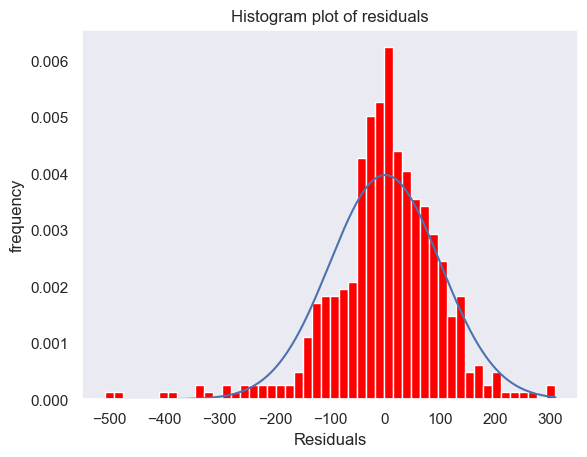

```python
residuals=(x@b)-y;

print("To test the normality of the residuals distribution:");
print(" ");
print(sp.stats.jarque_bera(residuals));

count,bins,ignored=plt.hist(residuals, 50, density=True, color='red');
minimum=np.min(residuals); maximum=np.max(residuals); mean=np.mean(residuals); sd=np.std(residuals);
x_axis=np.arange(minimum,maximum,0.01);
plt.plot(x_axis,norm.pdf(x_axis,mean,sd));
plt.title("Histogram plot of residuals");
plt.xlabel("Residuals");
plt.ylabel("frequency");
plt.grid();
plt.show();
```

| Jarque–Bera test |  |
| --- | --- |
| Null Hypothesis ($H_{0}$): | Skewness is zero and the excess kurtosis is zero. |
| Alternative Hypothesis ($H_{a}$): | Skewness is greater than zero and also excess kurtosis is greater than zero. |

The Jarque-Berra test returned a Jarque-Berra statistics, $\text{JB}=321$, which has a $\text{p-value}=0$; with an chosen $\alpha=0.05$, $\text{p-value}=0 < \alpha=0.05$, and so, reject the Hull hypothesis, $H_{0}$, the residuals possesses a non-gaussian distribution, which violates **MR6.**: $e \sim N(0,\sigma^{2})$.  
A convenience of `OLS` is that it provides the user with t-statistics, p-values and confidence intervals for each of the linear estimators, which make parameter hypothesis testing a ease to perform; where the following Hypothesis test,

| Parameter Hypothesis Test |  |
| --- | --- |
| Null Hypothesis ($H_{0}$): | $\beta = 0$, no relationship exists between independent variable and the dependent variable. |
| Alternative Hypothesis ($H_{a}$): | $\beta \neq 0$, a relationships exists between independent variable and the dependent variable. |

[figure not shown]

Figure 2 - Alternative functional forms for linear regression.

Linear regression possesses alternative functional forms that can help it model a non-linear dependent variable, or in our case non-gaussian distributed dependent variable 'price'. Due to the non-gaussian nature of 'price', the log-linear model would coerce 'price' to take on a more gaussian distribution, while allowing the linear regression model to capture more non-linear behavior.  
The follwing table contains useful information on each of the alternative functional forms.

[figure not shown]

Figure 3 - Helpful table for alternative functional forms.

To implement the Log-linear alternative functional form of linear regression, we only need to pass the dependent variable 'price' through the natural log function, $f(x)=\ln(x)$: this was completed with `Loggedy=np.log(y);`, and the newly logged dependent variable was named `loggedy`.

```python
Loggedy=np.log(y);
[Q,R,error]=QR_by_Given(x);
Q=Q[:,0:x.shape[1]];
R=R[0:x.shape[1],0:x.shape[1]];
beta=np.linalg.inv(R)@Q.T@Loggedy;
beta
```

```
Factorization error = 1.013215997145991e-12 Error of Orthogonal matrix = 1.6093983767878985e-14
```

```
array([0.03291839, 0.00713496, 0.03301364, 0.0985606 , 0.17559545,
       0.05830793, 0.16889691, 4.19578622])
```

As expected the factorization and orthogonality errors would quite small, and therefore QR decomposition with the new linear system was successful. To compare results and attain useful statistical tests, the `OLS` function was executed with the newly transformed dependent variable.

```python
model=sm.OLS(Loggedy,x)
results=model.fit()
print(results.summary())
```

```
                            OLS Regression Results
==============================================================================
Dep. Variable:                      y   R-squared:                       0.618
Model:                            OLS   Adj. R-squared:                  0.612
Method:                 Least Squares   F-statistic:                     113.6
Date:                Thu, 22 Jun 2023   Prob (F-statistic):           1.55e-98
Time:                        23:41:59   Log-Likelihood:                -123.70
No. Observations:                 500   AIC:                             263.4
Df Residuals:                     492   BIC:                             297.1
Df Model:                           7
Covariance Type:            nonrobust
==============================================================================
                 coef    std err          t      P>|t|      [0.025      0.975]
------------------------------------------------------------------------------
x1             0.0329      0.002     20.021      0.000       0.030       0.036
x2             0.0071      0.008      0.859      0.391      -0.009       0.023
x3             0.0330      0.058      0.564      0.573      -0.082       0.148
x4             0.0986      0.032      3.053      0.002       0.035       0.162
x5             0.1756      0.030      5.835      0.000       0.116       0.235
x6             0.0583      0.045      1.288      0.198      -0.031       0.147
x7             0.1689      0.029      5.913      0.000       0.113       0.225
const          4.1958      0.086     48.635      0.000       4.026       4.365
==============================================================================
Omnibus:                        8.164   Durbin-Watson:                   0.871
Prob(Omnibus):                  0.017   Jarque-Bera (JB):               10.068
Skew:                          -0.179   Prob(JB):                      0.00651
Kurtosis:                       3.596   Cond. No.                         189.
==============================================================================

Notes:
[1] Standard Errors assume that the covariance matrix of the errors is correctly specified.
```

After parameter hypothesis testing the unbiased least squares parameters, $\tilde{x} = [\hat{\beta}_{1},\hat{\beta}_{2},\ldots,\hat{\beta}_{7},\hat{\beta}_{0}]^{T}$; it was determined that independent variable's $x2$, $x3$, and $x6$ in this new version of the linear regression did not share a relationship with the dependent variable, 'price', and so, $\hat{\beta}_{2}$, $\hat{\beta}_{3}$ and $\hat{\beta}_{6}$ were determined to be equal to zero; while independent variables $x1$, $x4$, $x5$, $x7$, and $x0$ had a relationship, and therefore their betas, $\hat{\beta}_{1}$, $\hat{\beta}_{5}$, $\hat{\beta}_{7}$ and $\hat{\beta}_{0}$ were not zero. An additional note is that the confidence intervals least square estimators is much tighter than the last model, hence they must possess small variated normal distributions, and so, $\text{Var}(\hat{\beta}_{i}) < \text{Var}(\beta_{i})$, and so, by Gauss-Markov theorem $\hat{\beta}_{i}$ are the best linear unbiased estimators (BLUE). To demonstrate further that this new linear regression model better fits the dependent variable, we generated another histogram plot of the residuals.

```
To test the normality of the residuals distribution:

SignificanceResult(statistic=10.068074874047197, pvalue=0.0065124637572506845)
```

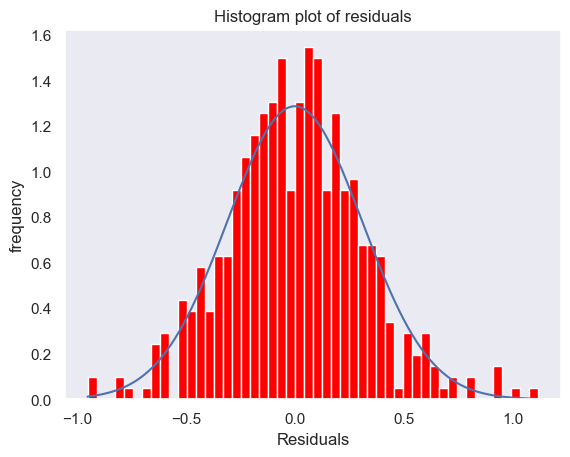

```python
Residuals=(x@beta)-Loggedy;

print("To test the normality of the residuals distribution:");
print(" ");
print(sp.stats.jarque_bera(Residuals));

count,bins,ignored=plt.hist(Residuals, 50, density=True, color='red');
minimum=np.min(Residuals); maximum=np.max(Residuals); mean=np.mean(Residuals); sd=np.std(Residuals);
x_axis=np.arange(minimum,maximum,0.01);
plt.plot(x_axis,norm.pdf(x_axis,mean,sd));
plt.title("Histogram plot of residuals");
plt.xlabel("Residuals");
plt.ylabel("frequency");
plt.grid();
plt.show();
```

Despite the residuals sample taking on a more approximate gaussian distribution, the Jarque-Berra test returned a Jarque-Berra statistics, $\text{JB}=10$, which has a $\text{p-value}=0.007$; with an chosen $\alpha=0.05$, $\text{p-value}=0.007 < \alpha=0.05$, and which we still reject the Hull hypothesis, $H_{0}$, the residuals does not possess a gaussian distribution; but we can observe clearly that the residuals possesses a approximately gaussian distribution as stipulated in assumption **MR 6.** of Gauss-Markov theorem assumptions (or Multiple Regression model assumptions).  
Key-take-away from pg. 142 to pg. 143 from Principles of Econometrics, Fourth Edition by R. Carter Hill, William E. Griffith and Guay C. Lim, is that there are different alternative functional forms that can help linear regression to fit data. And even more so that non-linear behavior can be captured by these alternative functional forms, which cannot be captured by classical linear least squares alone. In addition, though linear least squares gaurantees unbiased and consistent linear estimators, it cannot gaurantee that these linear estimators are efficient parameters; only a linear system that properly captures the behavior of the data will result in BLUE.

### 5. Conclusion

Linear least squares is linear regression, the least squares approximation $\hat{x}$ are the unbiased linear estimators that make-up the linear regression function. Even though the least squares estimators are gauranteed to be unbiased and consistent, there is no gaurantee that these unbiased linear estimators are efficent; hence BLUE.  
In addition, much of the assumptions such as Gauss-Markov six assumptions and conditions, such as, multicollinearity are based around mathematical phenomena from linear algebra, and much of the issues that linear regression models can faced find their origins back in linear algebra. For example the degree of which explanatory variables are linear depended upon each, determines the degree at which these variables are correlated with each other. Higher degrees of linear dependence, aka higher correlation, leads to $A^{T}A$ matrix being less of a Symmetric-Postitve definite (**SPD**) matrix, and more so a rank-deficient matrix, which thus means least square approximation $\bar{x}$ to the linear system $A^{T}Ax=A^{T}b$ become less reliable and sensitive. And so, the beta coefficients from the least square approximation are less reliable as they dramatically changed when explanatory variables are dropped or added to the linear regession model, and these beta coefficients possess large confidence intervals making even more difficult to discern the magnitude at which each explanatory variable is contributing toward the response variable. To address multicollinearity one could drop of the highly linearly dependent variables from the model to make the $A^{T}A$ matrix a more SPD matrix, thus improving the robustness of the least square solution $\bar{x}$. Another approach to address multicollinearity is to use Principal component analysis (**PCA**), so to reduces the number of dimensions of the explanatory variables dataset into their principal components; the purpose is to retain the original information while transforming the highly correlated explanatory variables into principal components, aka non-correlated explanatory variables, which also has the effect of improving the **SPD**-ness of matrix $A^{T}A$.  
In essence the features and limitations of linear regression are found in the phenoma of Linear Algebra. Understanding linear algebra allow one to appreciate both utility of linear regression, but so caution against it limitations. A good comprehension of linear algebra also faciliate an user ability to address a linear regression model limitation such as the case of multi-collinearity, under-fitting and overfitting, and hyper-parameter tuning.  
Anyhow, thank you for reading, we hope that this Jupyter notebook was hopeful, and that it could be used as a useful online resource. Lastly, we just want to wish the reader a wonderful day.

### Citations:

- [1]: Least Squares. Wikipedia, April 4, 2023.  
  Url: https://en.wikipedia.org/wiki/Least_squares
- [2]: Strang, Gilbert. Introduction to Linear Algebra, Fifth Edition. MIT, Wellesley-Cambridge Press. April 30, 2016.  
  Url: https://math.mit.edu/~gs/linearalgebra/ila5/indexila5.html
- [3]: Belk, James M. , Linear Algebra and Ordinary Differential Equations Notes - Week 10 - Subspaces, Linear Dependence. Cornell University, Department of Mathematics. June 23, 2023.  
  Url: https://e.math.cornell.edu/people/belk/writing/LinearODEs10.pdf
- [4]: Belk, James M. James M. Belk's personal website. Cornell University, Department of Mathematics. June 23, 2023.  
  Url: https://e.math.cornell.edu/people/belk/
- [5a]: Chan, Le. Math 221: Linear Algebra: textbook - Section 8-3. Positive Definite Matrices. Emory University, Department of Mathematics. June 23, 2023.  
  Url: https://math.emory.edu/~lchen41/teaching/2020_Fall/Section_8-3.pdf
- [5b]: Nicholson, We. Keith. Linear Algebra with Applications, Open Edition. June 23, 2023.  
  Url: https://math.emory.edu/~lchen41/teaching/2020_Fall/Nicholson-OpenLAWA-2019A.pdf
- [6]: Kolter, Zico. Editied by Honglak Lee. Convex Optimization Overview. Stanford University, Department of Computer Science.  
  Url: https://cs229.stanford.edu/section/cs229-cvxopt.pdf
- [7]: Rekkas, Marie. BUEC 333 D1: Statistical Analysis of Economic Data: CHAPTER 8: MULTICOLLINEARITY. Simon Fraser University, Department of Economics. June 23, 2023.  
  Url: https://www.sfu.ca/~dsignori/buec333/lecture%2016.pdf
- [8]: Kronecker Delta. Wikipedia, June 9, 2023.  
  Url: https://en.wikipedia.org/wiki/Kronecker_delta
- [9]: Machine Epsilon. Wikipedia, May 28, 2023.  
  Url: https://en.wikipedia.org/wiki/Machine_epsilon
- [10]: IEEE 754. Wikipedia, June 23, 2023.  
  Url: https://en.wikipedia.org/wiki/IEEE_754
- [11]: IEEE Standard for Floating-Point Arithmetic. IEEE Standard Association. June 23, 2023.  
  Url: https://standards.ieee.org/ieee/754/6210/
- [12]: Dave Kellen. Is there any reason to prefer the AIC or BIC over the other? - Answer. StackExchange. July 27, 2010.  
  Url: https://stats.stackexchange.com/questions/577/is-there-any-reason-to-prefer-the-aic-or-bic-over-the-other
- [13]: Singh, Aarti. 10-704: Information Processing and Learning: Lecture 13: Minimum Description Length. Carnegie Mellon University, School of Computer Science - Machine Learning Department. Spring 2012.  
  Url: https://www.cs.cmu.edu/~aarti/Class/10704/lec13-MDL.pdf
- [14]: Saad, Yousef. Iterative Methods for Sparse Linear Systems, Second edition. Society for Industrial and Applied Mathematics. 2003.  
  Url: https://doi.org/10.1137/1.9780898718003
- [15]: Saad, Yousef. Schultz, Martin H. GMRES: A Generalized Minimal Residual Algorithm for Solving Nonsymmetric Linear Systems. SIAM Journal of Scientific and Statistical Computing, vol. 7, pp. 856-869, 1986.  
  Url: https://doi.org/10.1137/0907058
- [16]: Schultz, Martin H. Faculty Retirement Tributes (2011) - Martin H. Schultz. Yale University, Computer Science Department. 2011.  
  Url: https://fas.yale.edu/book/faculty-retirement-tributes-2011/martin-h-schultz
- [17]: Brown, Peter N. Walker, Homer F. GMRES On (Nearly) Singular Systems. SIAM Journal of Matrix Analysis and Applications, Vol. 18, No. 1, pp. 37–51, January 1997.  
  Url: https://users.wpi.edu/~walker/Papers/gmres-singular,SIMAX_18,1997,37-51.pdf
- [18]: Reichel, Lothar. Ye, Qiang. Breakdown-Free GMRES For Singular System. SIAM Journal of Matrix Analysis and Applications, Vol. 26, No. 4, pp. 1001–1021. 2005.  
  Url: https://doi.org/10.1137/S0895479803437803
- [19]: Statsmodels Development Team. statsmodels/statsmodels/regression/linear_model.py. Github, June 23, 2020.  
  Url: https://github.com/statsmodels/statsmodels/blob/main/statsmodels/regression/linear_model.py
- [20]: Pollock, D. Stephen G. The Gauss-Markov Theorem. University of Leicester, Department of Economics. June 23, 2023.  
  Url: https://github.com/statsmodels/statsmodels/blob/main/statsmodels/regression/linear_model.py
- [21]: Hill, R. Carter. Griffiths, William E. Lim, Gauy C. Principles of Econometrics, Fourth Edition. Wiley. January 4, 2011.  
  Url: http://principlesofeconometrics.com/poe4/poe4.htm